# Supplementary information 4 RNAseq analysis for healthy vs multiple myeloma cells from GSE175384

TFM: Drug repurposing for multiple myeloma using SAveRUNNER in R Máster en Bioinformática y Bioestadística UoC y UB

Sergio Carracedo Huroz

# 1 Abstract

En este informe se muestran genes diferencialmente expresados en muestras de pacientes adultos con mieloma múltiple, así como los correspondientes procesos biológicos enrriquecidos.

# 2 Materials and Methods

## 2.1 Software

El análisis bioinformático presentado en este informe esta basado en el lenguaje R (R version 4.0.3 (2020-10-10)) y el uso de RStudio como interfaz de usuario, donde se han usado los siguientes paquetes tanto del repositorio `CRAN` como del repositorio de `Bioconductor`:

```r
# Librerías a usar en este informe:
library(Biobase)
library(stringr)
library(DESeq2)
library(dplyr)
library(ggplot2)
library(pheatmap)
library(RColorBrewer)
library(org.Hs.eg.db)
library(ReactomePA)
library(reactome.db)
library(AnnotationDbi)
library(genefilter)
library(ggbeeswarm)
library(apeglm)
```

## 2.2 Data and study design

El conjunto de datos usados en este informe procede de muestras de sangre de adulto sano y con mieloma múltiple del estudio con **[PMID:34133718](https://ashpublications.org/blood/article-abstract/doi/10.1182/blood.2020009754/476203/Tumor-cells-in-light-chain-amyloidosis-and-myeloma?redirectedFrom=fulltext)** para detectar genes diferencialmente expresados mediante el uso de la tecnología RNAseq (plataforma Illumina Genome Analyzer II) [1]. Los datos completos originales se encuentran disponibles en el repositorio *Gene expression omnibus (GEO)* bajo el accession number **GSE175384**. No obstante, **en este estudio sólo se analizan datos de humanos adultos sanos vs con mieloma múltiple**.

En cuanto al tipo de estudio, el análisis aquí presentado puede clasificarse como un **estudio comparativo** (*Class comparison*), ya que se comparan muestras de la especie humana de adulto sano y con mieloma múltiple.

El **método de análisis** de datos usado en este informe se basa en el paquete `DESeq2` y sigue un pipeline similar al usado en el informe *RNASeqBiocPipeline.html*, al cual se accede a partir del enlace:

https://github.com/ASPteaching/Omics_data_analysis-Case_study_2-RNA-seq

Sin embargo, se introducen algunas variaciones como, por ejemplo, el análisis de enrriquecimiento, el cual no está incluído en dicha plantilla.

# 3 Results

Fijaremos primero nuestro directorio de trabajo para almacenar y cargar nuestros datos desde el mismo, así como también crearemos directorios de almacenamiento de datos y directorios:

```r
# Establecemos directorio de trabajo:
setwd(dirname(rstudioapi::getSourceEditorContext()$path))

dir.create("Results") # almacenamiento de resultados
```

```r
dir.create("Results/Figures") # almacenamiento de figuras
# Feature counts table
GSMdb<- read.csv('C:/Users/Owner/Google Drive/Master Bioinformatica UoC/TFM/GSEA_GSE175384/GSE175384_Counts.txt', header = T, sep = '\t',row.names = 1)
GSMdb[1:5,1:5]
```

```
         RNAseq1 RNAseq2 RNAseq3 RNAseq4 RNAseq5
5S_rRNA        0       0       0       0       0
7SK           80      43     297      22    1040
A1BG           2       0       4       9      36
A1BG-AS1      17      12      24       0      58
A1CF           0       1       0       0       2
```

```r
colnames(GSMdb) # Check dataframe sample names
```

```
  [1] "RNAseq1"   "RNAseq2"   "RNAseq3"   "RNAseq4"   "RNAseq5"   "RNAseq6"
  [7] "RNAseq7"   "RNAseq8"   "RNAseq74"  "RNAseq75"  "RNAseq76"  "RNAseq77"
 [13] "RNAseq80"  "RNAseq81"  "RNAseq82"  "RNAseq83"  "RNAseq78"  "RNAseq84"
 [19] "RNAseq85"  "RNAseq86"  "RNAseq79"  "RNAseq62"  "RNAseq60"  "RNAseq58"
 [25] "RNAseq53"  "RNAseq45"  "RNAseq40"  "RNAseq36"  "RNAseq63"  "RNAseq59"
 [31] "RNAseq71"  "RNAseq68"  "RNAseq65"  "RNAseq54"  "RNAseq46"  "RNAseq41"
 [37] "RNAseq33"  "RNAseq64"  "RNAseq61"  "RNAseq72"  "RNAseq69"  "RNAseq66"
 [43] "RNAseq55"  "RNAseq47"  "RNAseq42"  "RNAseq73"  "RNAseq70"  "RNAseq67"
 [49] "RNAseq56"  "RNAseq48"  "RNAseq43"  "RNAseq34"  "RNAseq37"  "RNAseq9"
 [55] "RNAseq57"  "RNAseq49"  "RNAseq38"  "RNAseq50"  "RNAseq44"  "RNAseq35"
 [61] "RNAseq39"  "RNAseq51"  "RNAseq52"  "RNAseq10"  "RNAseq11"  "RNAseq12"
 [67] "RNAseq13"  "RNAseq14"  "RNAseq15"  "RNAseq16"  "RNAseq17"  "RNAseq18"
 [73] "RNAseq19"  "RNAseq20"  "RNAseq21"  "RNAseq22"  "RNAseq23"  "RNAseq24"
 [79] "RNAseq25"  "RNAseq26"  "RNAseq27"  "RNAseq28"  "RNAseq29"  "RNAseq30"
 [85] "RNAseq31"  "RNAseq32"  "RNAseq87"  "RNAseq88"  "RNAseq89"  "RNAseq90"
 [91] "RNAseq91"  "RNAseq92"  "RNAseq93"  "RNAseq94"  "RNAseq95"  "RNAseq96"
 [97] "RNAseq97"  "RNAseq98"  "RNAseq99"  "RNAseq100" "RNAseq101" "RNAseq102"
[103] "RNAseq103" "RNAseq104" "RNAseq105" "RNAseq106" "RNAseq107" "RNAseq108"
[109] "RNAseq109" "RNAseq110" "RNAseq111"
```

```r
GSMdb <- GSMdb[,str_sort(colnames(GSMdb), numeric = T)] # order columns alphabetically
GSMdb <- GSMdb[,c(33:73,80:111)] # Select healthy and MM samples only
colnames(GSMdb)
```

```
 [1] "RNAseq33"  "RNAseq34"  "RNAseq35"  "RNAseq36"  "RNAseq37"  "RNAseq38"
 [7] "RNAseq39"  "RNAseq40"  "RNAseq41"  "RNAseq42"  "RNAseq43"  "RNAseq44"
[13] "RNAseq45"  "RNAseq46"  "RNAseq47"  "RNAseq48"  "RNAseq49"  "RNAseq50"
[19] "RNAseq51"  "RNAseq52"  "RNAseq53"  "RNAseq54"  "RNAseq55"  "RNAseq56"
[25] "RNAseq57"  "RNAseq58"  "RNAseq59"  "RNAseq60"  "RNAseq61"  "RNAseq62"
[31] "RNAseq63"  "RNAseq64"  "RNAseq65"  "RNAseq66"  "RNAseq67"  "RNAseq68"
[37] "RNAseq69"  "RNAseq70"  "RNAseq71"  "RNAseq72"  "RNAseq73"  "RNAseq80"
[43] "RNAseq81"  "RNAseq82"  "RNAseq83"  "RNAseq84"  "RNAseq85"  "RNAseq86"
[49] "RNAseq87"  "RNAseq88"  "RNAseq89"  "RNAseq90"  "RNAseq91"  "RNAseq92"
[55] "RNAseq93"  "RNAseq94"  "RNAseq95"  "RNAseq96"  "RNAseq97"  "RNAseq98"
[61] "RNAseq99"  "RNAseq100" "RNAseq101" "RNAseq102" "RNAseq103" "RNAseq104"
[67] "RNAseq105" "RNAseq106" "RNAseq107" "RNAseq108" "RNAseq109" "RNAseq110"
[73] "RNAseq111"
```

```r
any(is.na(GSMdb)) # Confirm lack of NA values
```

```
[1] FALSE
```

```r
# Target file
target_file <- read.csv('C:/Users/Owner/Google Drive/Master Bioinformatica UoC/TFM/GSEA_GSE175384/target_file_GSE175384.txt', header = F, sep = '\t')
target_file <- as.data.frame(t(target_file))
colnames(target_file) <- target_file[1,] # Set first row as column names
target_file <- target_file[-1,]
rownames(target_file) <- target_file$Sample_description # Set sample names as row names
target_file <- target_file[c(33:73, 80:111),] # Select healthy and MM samples only
head(target_file)
```

```
         Sample_source_name_ch1 Sample_description Sample_geo_accession
RNAseq33          Healthy adult           RNAseq33           GSM5332216
RNAseq34          Healthy adult           RNAseq34           GSM5332217
RNAseq35          Healthy adult           RNAseq35           GSM5332218
RNAseq36          Healthy adult           RNAseq36           GSM5332219
RNAseq37          Healthy adult           RNAseq37           GSM5332220
RNAseq38          Healthy adult           RNAseq38           GSM5332221
         Sample_organism_ch1 Sample_characteristics_ch1 Sample_taxid_ch1
RNAseq33        Homo sapiens    cell type: Plasma cells             9606
RNAseq34        Homo sapiens    cell type: Plasma cells             9606
RNAseq35        Homo sapiens    cell type: Plasma cells             9606
RNAseq36        Homo sapiens    cell type: Plasma cells             9606
RNAseq37        Homo sapiens    cell type: Plasma cells             9606
RNAseq38        Homo sapiens    cell type: Plasma cells             9606
```

```r
any(is.na(target_file)) # Confirm lack of NA values
```

```
[1] FALSE
```

```r
#Columns in GSMdb correspond to rows in target_file
all(rownames(target_file) == colnames(GSMdb) )
```

```
[1] TRUE
```

A continuación seguimos el pipeline:

- Identificación de grupos y muestras.
- Control de calidad de los datos crudos.
- Identificación de genes diferencialmente expresados.
- Anotación de los resultados.
- Comparación entre distintas comparaciones.
- Análisis de significación biológica.

## 3.1 Identification of groups and samples

```r
# Confirm that there are only Healthy and MM samples in target_file and therefore GSM dataframes
target_file$Sample_source_name_ch1 <- as.factor(target_file$Sample_source_name_ch1) # Factorize sample types
levels(target_file$Sample_source_name_ch1)
```

```
[1] "Healthy adult"    "Multiple myeloma"
```

```r
#Rename to avoid warnings when making the DESeqDataSet object:
levels(target_file$Sample_source_name_ch1) <- c('Healthy_Adult','Multiple_Myeloma')
```

```r
dds <- DESeqDataSetFromMatrix(countData = GSMdb,
                                 colData = target_file,
                                 design = ~ Sample_source_name_ch1)

# Renombramos muestras para una más fácil identificación:
colnames(dds)[which(target_file$Sample_source_name_ch1 == 'Healthy_Adult')] <- paste0('HA',1:length(which(target_file$Sample_source_name_ch1 == 'Healthy_Adult'))) #Rename healthy samples (RNAseq33-RNAseq73)
colnames(dds)[which(target_file$Sample_source_name_ch1 == 'Multiple_Myeloma')] <- paste0('MM',1:length(which(target_file$Sample_source_name_ch1 == 'Multiple_Myeloma'))) #Rename Multiple Myeloma samples (RNAseq80-RNAseq111)
```

## 3.2 Quality control of raw data

Debido a que el análisis se lleva a cabo a partir del ‘count table,’ asumimos que éstos son los datos crudos y por tanto aplicamos el control de calidad y demás análisis a los mismos.

### 3.2.1 Data pre-filtering

Muchas de las filas de `dds` corresponden a genes con expresión génica indetectable en todas las muestras y no contienen conteos (es decir, contienen solamente ceros), luego no son muy informativas. Por ello, procedemos a filtrar (elimininar) dichas filas para obtener un ´DESeqDataSet´ más pequeño que permita ejecutar las funciones aplicadas a este objeto con más rapidez. Para el filtraje usaremos en este caso el criterio más básico: Eliminar las filas de `dds` sin conteos o que bien contengan un único conteo teniendo en cuenta todas las columnas (muestras):

```r
# Número de genes inicial:
(a <- nrow(dds))
```

```
[1] 48495
```

```r
# Aplicamos prefiltraje:
dds <- dds[rowSums(counts(dds)) > 1, ]

# Genes en dds después del filtraje:
(b <- nrow(dds))
```

```
[1] 38403
```

Vemos que aproximadamente nos quedamos con un 79% del número inicial de genes contenidos en `dds`.

### 3.2.2 Normalization

Como se menciona en la plantilla *RNASeqBiocPipeline.html*, se recominenda **no normalizar los datos para identificar genes diferencialmente expresados mediante la función `DESeq()`**. Sin embargo, dichos datos sí que se normalizan para visualizarlos y obtener una idea de su calidad. Para ello, `DESeq2` ofrece dos tipos de transformaciones para datos de conteo que estabilizan la varianza sobre la media: variance stabilizing transformation (VST) [2], la cual se implementa con la función `vst()`, y regularized-logarithm (rlog) [3], implementada con la función `rlog`. Como también se recomienda en *RNASeqBiocPipeline.html*, en este caso elegimos la transformación VST para visualizar datos en gráficos posteriores ya que esta función se computa más rápidamente, es menos sensible que rlog a outliers con muchos conteos, y además tenemos en nuestro estudio muestras con muchos conteos (n>30).

```r
# Transformación VST:
vsd <- vst(dds,blind = F)
head(assay(vsd), 3)
```

```
             HA1      HA2      HA3      HA4      HA5      HA6      HA7      HA8
5S_rRNA 2.958605 2.958605 2.958605 2.958605 2.958605 2.958605 2.958605 2.958605
7SK     6.715553 6.170942 7.338183 6.776914 5.700961 6.835582 6.014751 6.619770
A1BG    3.984162 4.791890 2.958605 2.958605 2.958605 2.958605 2.958605 2.958605
             HA9     HA10     HA11     HA12     HA13     HA14     HA15     HA16
5S_rRNA 2.958605 2.958605 2.958605 2.958605 2.958605 2.958605 2.958605 2.958605
7SK     6.751929 6.264093 5.898076 7.645936 6.555222 6.156085 5.959378 5.957571
A1BG    6.104289 4.295318 3.814729 3.671762 3.599468 2.958605 3.680135 3.471025
            HA17     HA18     HA19     HA20     HA21     HA22     HA23     HA24
5S_rRNA 2.958605 2.958605 2.958605 2.958605 2.958605 2.958605 2.958605 2.958605
7SK     6.594346 7.513943 7.013151 7.280718 6.625613 6.060860 6.029992 5.971039
A1BG    5.951245 3.903409 2.958605 2.958605 2.958605 3.489245 2.958605 3.515846
            HA25     HA26     HA27     HA28     HA29     HA30     HA31     HA32
5S_rRNA 2.958605 2.958605 2.958605 2.958605 2.958605 2.958605 2.958605 2.958605
7SK     7.248848 6.102661 6.221417 7.200741 6.224079 6.420132 6.252154 6.424911
A1BG    3.174939 2.958605 2.958605 3.509561 2.958605 2.958605 3.744461 2.958605
            HA33     HA34     HA35     HA36     HA37     HA38     HA39     HA40
5S_rRNA 2.958605 2.958605 2.958605 2.958605 2.958605 2.958605 2.958605 2.958605
7SK     5.605050 6.872696 5.899393 5.876477 5.672048 5.771194 5.998740 5.994596
A1BG    2.958605 2.958605 2.958605 3.621252 3.457548 3.563186 3.896517 3.865138
            HA41      MM1      MM2      MM3      MM4      MM5      MM6      MM7
5S_rRNA 2.958605 2.958605 2.958605 2.958605 2.958605 2.958605 2.958605 2.958605
7SK     6.131761 6.788064 8.319301 6.848992 7.574760 7.061260 6.197098 6.079691
A1BG    3.613674 3.838839 2.958605 2.958605 3.361128 2.958605 2.958605 4.051083
             MM8      MM9     MM10     MM11     MM12     MM13     MM14     MM15
5S_rRNA 2.958605 2.958605 2.958605 2.958605 2.958605 2.958605 3.211904 2.958605
7SK     6.406924 5.904232 7.588464 6.636321 6.672569 6.980962 5.575149 7.618995
A1BG    3.689701 2.958605 4.057583 4.235992 3.807864 4.092775 3.891256 3.853411
            MM16     MM17     MM18     MM19     MM20     MM21     MM22     MM23
5S_rRNA 2.958605 2.958605 2.958605 2.958605 2.958605 3.661396 2.958605 2.958605
7SK     6.989718 5.908571 6.034957 5.593360 6.800926 8.743855 7.371348 6.081404
A1BG    3.881981 2.958605 2.958605 3.310782 3.506628 2.958605 3.796642 3.344163
            MM24     MM25     MM26     MM27     MM28     MM29     MM30     MM31
5S_rRNA 2.958605 2.958605 2.958605 2.958605 2.958605 3.360307 2.958605 2.958605
7SK     6.194950 5.022302 7.503259 7.096791 7.925577 8.454574 7.312612 8.439898
A1BG    5.025707 2.958605 3.595347 3.548723 3.578155 4.070723 3.654422 2.958605
            MM32
5S_rRNA 2.958605
7SK     7.456931
A1BG    2.958605
```

```r
# Transformación rlog si se deseara:
# rld <- rlog(dds, blind = FALSE)
# head(assay(rld), 3)

# Los datos sobre las muestras son aún accesibles:
colData(vsd)
```

```
DataFrame with 73 rows and 7 columns
     Sample_source_name_ch1 Sample_description Sample_geo_accession
                   <factor>        <character>          <character>
HA1           Healthy_Adult           RNAseq33           GSM5332216
HA2           Healthy_Adult           RNAseq34           GSM5332217
HA3           Healthy_Adult           RNAseq35           GSM5332218
HA4           Healthy_Adult           RNAseq36           GSM5332219
HA5           Healthy_Adult           RNAseq37           GSM5332220
...                     ...                ...                  ...
MM28       Multiple_Myeloma          RNAseq107           GSM5332290
MM29       Multiple_Myeloma          RNAseq108           GSM5332291
MM30       Multiple_Myeloma          RNAseq109           GSM5332292
MM31       Multiple_Myeloma          RNAseq110           GSM5332293
MM32       Multiple_Myeloma          RNAseq111           GSM5332294
     Sample_organism_ch1 Sample_characteristics_ch1 Sample_taxid_ch1 sizeFactor
             <character>                <character>      <character>  <numeric>
HA1         Homo sapiens    cell type: Plasma cells             9606   0.244112
HA2         Homo sapiens    cell type: Plasma cells             9606   0.488298
HA3         Homo sapiens    cell type: Plasma cells             9606   1.466186
HA4         Homo sapiens    cell type: Plasma cells             9606   0.274652
HA5         Homo sapiens    cell type: Plasma cells             9606   0.504875
...                  ...                        ...              ...        ...
MM28        Homo sapiens    cell type: Plasma cells             9606   1.373832
MM29        Homo sapiens                       cell             9606   1.648572
MM30        Homo sapiens                                        9606   1.084819
MM31        Homo sapiens                                        9606   0.762294
MM32        Homo sapiens                                        9606   1.539020
```

En la figura 3.1 vemos algunas diferencias entre medianas y el percentil 75 entre muestras.

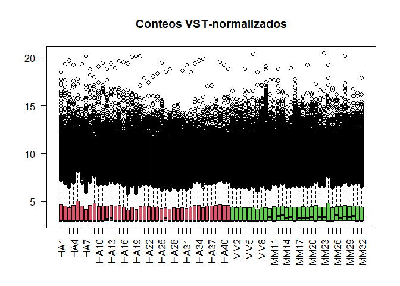

Figure 3.1: Boxplot de los datos transformados por el método VST

```r
# ColoR <- c()
# for(i in 2:(length(unique(colData(dds)$Sample_source_name_ch1))+1)){
#   a <-rep(i,length(colData(dds)$Sample_source_name_ch1[colData(dds)$Sample_source_name_ch1==unique(colData(dds)$Sample_source_name_ch1)[i]]))
#   ColoR <- c(ColoR,a)
# }
boxplot(assay(vsd), las=2, main=" Conteos VST-normalizados ", col=c(rep(2,41),rep(3,32)))
```

```r
#Guardamos figura:
jpeg("Results/Figures/Boxplot_VST_transformed_data.jpeg", res = 200, width = 20, height = 16, units = 'in')
boxplot(assay(vsd), las=2, main=" Conteos VST-normalizados ", col=c(rep(2,41),rep(3,32)))
dev.off()
```

### 3.2.3 Distances among samples (heatmap)

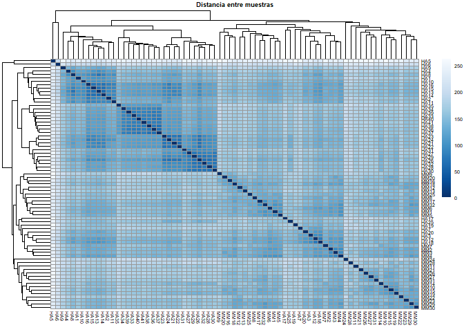

Figure 3.2: Heatmap mostrando las distancias entre muestras usando los valores transformados mediante VST.

```r
# Distancias entre muestras:
sampleDists <- dist(t(assay(vsd)))


# Visualización de distancias mediante heatmap:
sampleDistMatrix <- as.matrix( sampleDists )
colors <- colorRampPalette( rev(brewer.pal(9, "Blues")) )(255)
pheatmap(sampleDistMatrix,
         clustering_distance_rows = sampleDists,
         clustering_distance_cols = sampleDists,
         col = colors, main = 'Distancia entre muestras',
         fontsize = 5)
```

```r
dev.off()
```

```r
#Guardamos figura:
jpeg("Results/Figures/Heatmap_Distancia_entre_muestras.jpeg", res = 200, width = 20, height = 16, units = 'in')
pheatmap(sampleDistMatrix,
         clustering_distance_rows = sampleDists,
         clustering_distance_cols = sampleDists,
         col = colors, main = 'Distancia entre muestras',
         fontsize = 5)
dev.off()
```

Parece que un grupo de muestras de pacientes sanos se diferencia del resto.

### 3.2.4 PCA plot

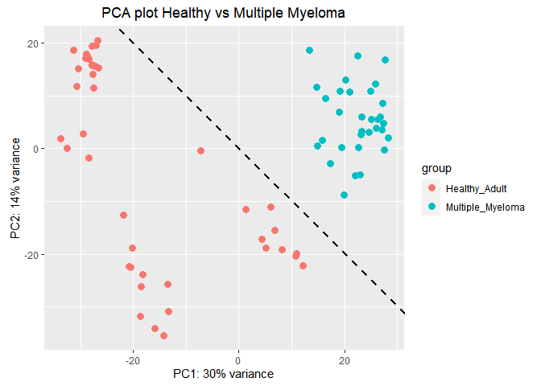

Figure 3.3: PCA plot de las muestras usadas en este estudio.

```r
plotPCA(vsd,intgroup='Sample_source_name_ch1')+ggtitle('PCA plot Healthy vs Multiple Myeloma') +
   theme(plot.title = element_text(hjust = 0.5)) + geom_abline(intercept =0,slope = -1,lwd=1, lty=2)
```

```r
#Guardamos figura:
jpeg("Results/Figures/PCA_plot_Healthy_vs_MM.jpeg", res = 200, width = 10, height = 8, units = 'in')
plotPCA(vsd,intgroup='Sample_source_name_ch1')+ggtitle('PCA plot Healthy vs Multiple Myeloma') +
   theme(plot.title = element_text(hjust = 0.5)) + geom_abline(intercept =0,slope = -1,lwd=1, lty=2)
dev.off()
```

Vemos que, si bien el PCA plot muestra separación de muestras de acuerdo al PC1 y parcialmente al PC2 según sean sanas o MM, al considerar ambas PCs simultáneamente, se podría trazar una línea de pendiente negativa que podría separar las muestras de diferente tipo (linea discontínua en 3.3).

### 3.2.5 MDS plot

El escalado multidimensional (MDS) también busca similaridades entre muestras usando diferentes algoritmos basados en transformaciones de distancias entre los datos de las mismas, siendo de hecho el PCA un caso particular de MDS. Por tanto, en un MDS plot podríamos esperar obtener una separación relativamente similar a la obtenida en el PCA plot:

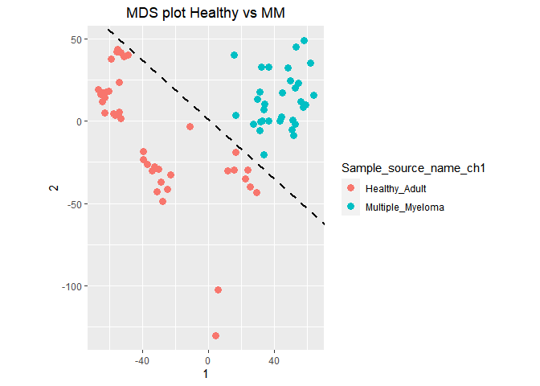

Figure 3.4: MDS plot de las muestras usadas en este estudio.

```r
mds <- as.data.frame(colData(vsd))  %>%
         cbind(cmdscale(sampleDistMatrix))
ggplot(mds, aes(x = `1`, y = `2`, color = Sample_source_name_ch1)) +
  geom_point(size = 3) + coord_fixed() +
  geom_abline(intercept =1,slope =- .9,lwd=1, lty=2)+
  ggtitle('MDS plot Healthy vs MM') +
   theme(plot.title = element_text(hjust = 0.5))
```

```r
#Guardamos figura:
jpeg("Results/Figures/MDS_plot_Healthy_and_MM_samples.jpeg", res = 200, width = 10, height = 8, units = 'in')
ggplot(mds, aes(x = `1`, y = `2`, color = Sample_source_name_ch1)) +
  geom_point(size = 3) + coord_fixed() +
  geom_abline(intercept =1,slope =- .9,lwd=1, lty=2)+
  ggtitle('MDS plot Healthy vs MM') +
   theme(plot.title = element_text(hjust = 0.5))
dev.off()
```

En la figura 3.4 vemos que, en este caso, también obtenemos una separación entre muestras sanas y con MM de manera similar al caso del PCA plot.

## 3.3 Identification of differentially expressed genes (DEGs)

Para identificar los DEGs usamos primeramente la función `DESseq()`, para la cual se han de usar los datos crudos (objeto `dds` que creamos anteriormente). Con ello se genera un objeto `DESseqDataSet` , el cual se usa a su vez como argumento en la función `results()` junto con el contraste que deseamos para obtener una tabla con los resultados estadísticos y logFC para cada gen:

```r
dds <- DESeq(dds, parallel =F)

res <- results(dds,contrast = c('Sample_source_name_ch1','Multiple_Myeloma','Healthy_Adult'))

# Eliminamos valores NA:
res <- na.omit(res)

# Número de DEGs de acuerdo al criterio de corte
table(res$padj < 0.05 & abs(res$log2FoldChange) > 1)
```

```
FALSE  TRUE
17622  6609
```

Podemos mirar los metadatos de `res` para saber qué significa cada columna en la tabla anterior:

```r
mcols(res, use.names = TRUE)
```

```
DataFrame with 6 rows and 2 columns
                       type
                <character>
baseMean       intermediate
log2FoldChange      results
lfcSE               results
stat                results
pvalue              results
padj                results
                                                                                    description
                                                                                    <character>
baseMean                                              mean of normalized counts for all samples
log2FoldChange log2 fold change (MLE): Sample_source_name_ch1 Multiple_Myeloma vs Healthy_Adult
lfcSE                  standard error: Sample source name ch1 Multiple Myeloma vs Healthy Adult
stat                   Wald statistic: Sample source name ch1 Multiple Myeloma vs Healthy Adult
pvalue              Wald test p-value: Sample source name ch1 Multiple Myeloma vs Healthy Adult
padj                                                                       BH adjusted p-values
```

- **baseMean** es el promedio de los valores de conteo normalizados, dividido por los factores de tamaño tomados de todas las muestras en DESeqDataSet.
- **log2FoldChange** es la estimación del tamaño del efecto. Nos dice cuánto parece haber cambiado la expresión del gen debido la condición experimental (sano vs mieloma múltiple).
- **lfcSE** es la estimación del error estándar para la estimación del log2FoldChange.
- **padj** es el p-valor ajustado usando el ajuste por el método de Benjamini-Hochberg.

También podemos ver un resumen de los resultados:

```r
summary(res)
```

```
out of 24231 with nonzero total read count
adjusted p-value < 0.1
LFC > 0 (up)       : 6407, 26%
LFC < 0 (down)     : 5229, 22%
outliers [1]       : 0, 0%
low counts [2]     : 0, 0%
(mean count < 0)
[1] see 'cooksCutoff' argument of ?results
[2] see 'independentFiltering' argument of ?results
```

### 3.3.1 Volcano plot

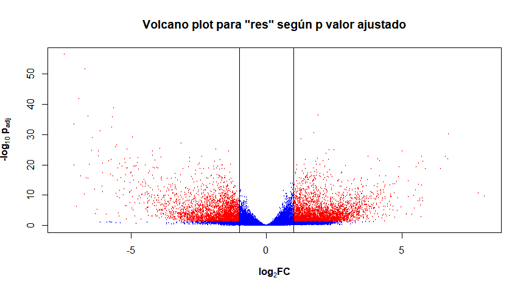

```r
# par(mfrow=c(1,2))

#Volcano plot usando p valor ajustado:
plot(res$log2FoldChange,-log10(res$padj),main=paste('Volcano plot para "res" según p valor ajustado',sep = '\n'),cex= .3,col=ifelse(res$padj <0.05 & abs(res$log2FoldChange) >1,'red','blue'),xlab = expression(bold('log'[2]*'FC')),ylab = expression(bold('-log'[10]*' p'[adj])))
abline(v=c(-1,1))
```

```r
# # Volcano plot usando p valor:
# plot(res$log2FoldChange,-log10(res$pvalue),main=paste('Volcano plot para "res"','según p valor',sep = '\n'),cex= .3,col='blue')
# abline(v=c(-1,1))

par(mfrow=c(1,1))

#Guardamos figura:
jpeg("Results/Figures/Volcano_plot_Healthy_and_MM_samples.jpeg", res = 200, width = 10, height = 8, units = 'in')
plot(res$log2FoldChange,-log10(res$padj),main=paste('Volcano plot Healthy vs MM samples',sep = '\n'),cex= .3,col='blue',xlab = expression(bold('log'[2]*'FC')),ylab = expression(bold('-log'[10]*' p'[adj])))
abline(v=c(-1,1))
dev.off()
```

Al tener el objeto `res` usaremos como criterio el p-valor ajustado ($\alpha$ < 0.05) y valor de corte de valor absoluto de log2FC > 1 para obtener DEGs, el cual usaremos posteriormentec en las secciones de visualización y análisis de significación biológica de DEGs:

```r
res <- res[res$padj < 0.05 & abs(res$log2FoldChange) > 1 ,]

#Guardado de archivos:
write.csv(as.data.frame(res),
             file ="Results/DEGs_Healthy_vs_MM_Log2FC_1_Padj0.05.csv",
             row.names = T)
```

## 3.4 Gene annotation

Para anotar la tabla `res` con los correspondientes nombres de genes extraemos las columnas pertinentes de nuestra base de datos de anotaciones (`org.Hs.eg.db`) y las fusionamos con `res`. En este caso, previamente se debe añadir una columna con los símbolos de genes a `res` que servirá de referencia para dicha fusión:

```r
# Se añade columna con identificadores ENSEMBL:
res.annotated <- cbind(SYMBOL=rownames(res), res)

# Selección de columnas de interés de org.Hs.eg.db:
geneAnots <- AnnotationDbi::select(org.Hs.eg.db, keys=res.annotated[,"SYMBOL"], keytype='SYMBOL',columns=c("SYMBOL", "ENTREZID", "GENENAME"))

# Fusión de columnas seleccionadas en paso anterior con res.annotated según SYMBOL:
res.annotated <- merge(x=geneAnots, y=res.annotated, by.x="SYMBOL", by.y="SYMBOL")

# Reordenamiento de la tabla de acuerdo al p-valor ajustado:
topTab <- res.annotated[order(res.annotated$padj),]
topTab <- topTab[-which(is.na(topTab$ENTREZID)),]

#Guardado de archivos:
write.csv(as.data.frame(topTab),
             file ="Results/Annotated_DEGs_Healthy_vs_MM_Log2FC_1_Padj0.05.csv",
             row.names = F)
write.table(as.data.frame(as.numeric(topTab$ENTREZID[order(topTab$log2FoldChange,decreasing = T)])[1:300]),
             file ="Results/Top_300_logFC_Upregulated_Annotated_DEGs_Healthy_vs_MM_Log2FC_1_Padj0.05.txt",
             row.names = F,col.names = F)
write.table(as.data.frame(as.numeric(topTab$ENTREZID[order(topTab$log2FoldChange,decreasing = F)])[1:300]),
             file ="Results/Top_300_logFC_Downregulated_Annotated_DEGs_Healthy_vs_MM_Log2FC_1_Padj0.05.txt",
             row.names = F,col.names = F)
# Visualización de tabla anotada en una tabla:
knitr::kable(head(topTab),booktabs = TRUE,
             caption = 'Seis primeros genes anotados de la lista topTab ordenados según su p valor')
```

Table 3.1: Seis primeros genes anotados de la lista topTab ordenados según su p valor

| SYMBOL | ENTREZID | GENENAME | baseMean | log2FoldChange | lfcSE | stat | pvalue | padj |
| --- | --- | --- | --- | --- | --- | --- | --- | --- |
| IGLV1-40 | 28825 | immunoglobulin lambda variable 1-40 | 123.76172 | -7.443295 | 0.4501477 | -16.53523 | 0 | 0 |
| IGLV1-51 | 28820 | immunoglobulin lambda variable 1-51 | 76.19090 | -6.686168 | 0.4226511 | -15.81959 | 0 | 0 |
| IGLV4-69 | 28784 | immunoglobulin lambda variable 4-69 | 48.89679 | -6.900870 | 0.4828389 | -14.29228 | 0 | 0 |
| IGLV8-61 | 28774 | immunoglobulin lambda variable 8-61 | 41.50966 | -5.619471 | 0.4073438 | -13.79540 | 0 | 0 |
| ARPC5L | 81873 | actin related protein 2/3 complex subunit 5 like | 576.42103 | 1.929150 | 0.1443223 | 13.36695 | 0 | 0 |
| IGLV7-46 | 28775 | immunoglobulin lambda variable 7-46 (gene/pseudogene) | 44.90491 | -6.556131 | 0.4931229 | -13.29513 | 0 | 0 |

```r
# Save table with annotated DEGs as image:
library(ggplot2)
library(gridExtra)
png("C:/Users/Owner/Google Drive/Master Bioinformatica UoC/TFM/Figuras/20 DEGs_Log2FC_1_Padj0.05 anotados con menor Padj en MM GSE175384.png", res=200,height=140*nrow(head(topTab, 20)), width=400*ncol(head(topTab, 20)))
p<-tableGrob(head(topTab, 20))
grid.arrange(p)
dev.off()
```

## 3.5 Graphical representations of results.

### 3.5.1 Counts plot

Una manera rápida para visualizar los conteos de un gen en particular es usar la función `plotCounts`, la cual toma como argumentos el objeto `DESeqDataSet`, el nombre del gen y el grupo sobre el cual se separan los datos a visualizar. A continuación se muestra el Count plot para el gen diferencialmente expresado de manera más significativa (menor p valor ajustado):

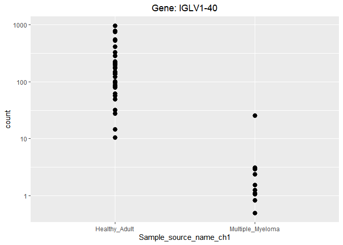

Figure 3.6: Visualización de datos de conteo para el DEG más significativo.

```r
# Añadimos identificadores SYMBOL a nombres de filas:
rownames(topTab) <- topTab$SYMBOL

# Seleccionamos el DEG más significativo:
topGene <- rownames(topTab)[which.min(topTab$padj)]

# Datos de conteo para DEG más significativo en cada muestra:
geneCounts <- plotCounts(dds, gene = topGene, intgroup = 'Sample_source_name_ch1',
                         returnData = TRUE)

# Representación de conteos para cada muestra:
ggplot(geneCounts, aes(x = Sample_source_name_ch1, y = count)) +
  scale_y_log10() + geom_point(size = 3) +
  ggtitle(paste0('Gene: ',topTab$SYMBOL[which(topTab$SYMBOL==topGene)])) +
  theme(plot.title = element_text(hjust = 0.5))
```

```r
#Guardamos figura:
jpeg("Results/Figures/Most_variable_gene.jpeg", res = 200, width = 5, height = 4, units = 'in')
ggplot(geneCounts, aes(x = Sample_source_name_ch1, y = count)) +
  scale_y_log10() + geom_point(size = 3) +
  ggtitle(paste0('Gene: ',topTab$SYMBOL[which(topTab$SYMBOL==topGene)])) +
  theme(plot.title = element_text(hjust = 0.5))

dev.off()
```

### 3.5.2 MA plot

El MA plot proporciona una descripción general útil para la distribución de los coeficientes estimados en el modelo, es decir, las comparaciones de interés, en todos los genes. Un MA plot con un alto número de puntos de datos por encima del umbral en el eje de ordenadas indicaría un mayor número de genes sobreexpresados, mientras que más puntos por debajo de -1 indicaría un número mayor de genes infraexpresados [4].

Antes de realizar el gráfico MA, usamos la función `lfcShrink` para reducir los log2FC para la comparación de muestras sanas vs mieloma múltiple. Entre otros métodos, DESeq2 ofrece el método `apeglm` para reducir los coeficientes, el cual es bueno para reducir las estimaciones de LFC que se considerarían ruido al mismo tiempo que proporciona estimaciones de LFC de bajo sesgo para diferencias verdaderamente grandes [5]. Para usar `apeglm`, especificamos un coeficiente a encoger del modelo entre los que aparecen en `resultsNames (dds)`. En nuestro caso sólo tenemos el coeficiente correspondiente a la comparación sano vs mieloma múltiple:

```r
resultsNames(dds)
```

```
[1] "Intercept"
[2] "Sample_source_name_ch1_Multiple_Myeloma_vs_Healthy_Adult"
```

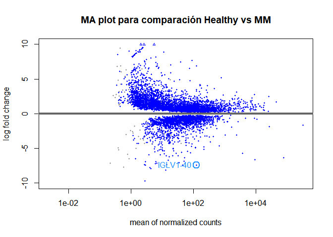

```r
MAdata <- lfcShrink(dds, coef="Sample_source_name_ch1_Multiple_Myeloma_vs_Healthy_Adult", type="apeglm")
plotMA(MAdata, main = 'MA plot para comparación Healthy vs MM', ylim = c(-10,10))
topGene <- rownames(MAdata)[which.min(MAdata$padj)]
with(MAdata[topGene, ], {
  points(baseMean, log2FoldChange, col="dodgerblue", cex=2, lwd=2)
  text(baseMean, log2FoldChange, topGene, pos=2, col="dodgerblue")
})
```

```r
#Guardamos figura:
jpeg("Results/Figures/MA_plot_Healthy_vs_MM.jpeg", res = 200, width =15, height = 12, units = 'in')
plotMA(MAdata, main = 'MA plot para comparación Healthy vs MM')
topGene <- rownames(MAdata)[which.min(MAdata$padj)]
with(MAdata[topGene, ], {
  points(baseMean, log2FoldChange, col="dodgerblue", cex=2, lwd=2)
  text(baseMean, log2FoldChange, topGene, pos=2, col="dodgerblue")
})

dev.off()
```

### 3.5.3 Heatmap for DEGs

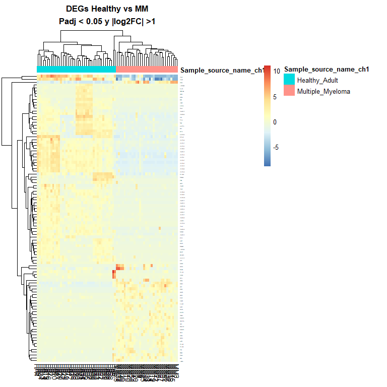

Figure 3.8: Heatmap para los 100 DEGs con mayor variabilidad entre muestras.

```r
# Indice para los 30 DEGs con mayor variabilidad entre muestras:

topVarGenes <- head(order(abs(topTab$log2FoldChange), decreasing = TRUE), 100)

# Selección de genes en la tabla de conteos normalizada:
mat  <- assay(vsd)[topTab$SYMBOL,][topVarGenes, ]

# Centrado de datos:
mat  <- mat - rowMeans(mat)

# Dataframe con el tipo de muestra:
anno <- as.data.frame(colData(vsd)[, "Sample_source_name_ch1"])

# Generación del heatmap:
colnames(anno)='Sample_source_name_ch1'
rownames(anno) <- colnames(mat)
pheatmap(mat, annotation_col = anno,labels_row=topTab$SYMBOL[topVarGenes],main =paste( "DEGs Healthy vs MM",'Padj < 0.05 y |log2FC| >1',sep = '\n'),fontsize_row=1)
```

```r
dev.off()
```

```r
#Guardamos figura:
jpeg("Results/Figures/Heatmap_DEGs_Healthy_vs_MM.jpeg_Log2FC_1_Padj0.05.jpeg", res = 200, width = 20, height = 40, units = 'in')
pheatmap(mat, annotation_col = anno,labels_row=topTab$SYMBOL[topVarGenes],main =paste( "DEGs Healthy vs MM",'Padj < 0.05 y |log2FC| >1',sep = '\n'))

dev.off()
```

## 3.6 DEGs for multiple comparisons

Para visualizar simultáneamente genes diferencialmente expresados en distintas comparaciones se podría usar un diagrama tipo Venn. Sin embargo, en este estudio se realiza una única comparación entre muestras (sano vs mieloma multiple), por lo que en este caso no existe posibilidad de comparación múltiple ni de generar el diagrama Venn correspondiente.

## 3.7 Gene Set Enrichment Analysis (GSEA)

Primeramente mapeamos pues todos los genes del genoma humano y definiremos como nuestro universo todos los genes que tienen al menos una anotación en Gene Ontology o KEGG:

```r
mapped_genes2GO <- mappedkeys(org.Hs.egGO)
mapped_genes2KEGG <- mappedkeys(org.Hs.egPATH)
mapped_genes <- union(mapped_genes2GO , mapped_genes2KEGG)
```

A continuación procedemos al análisis de significación biológica usando `enrichPathway()`, para lo cual **establecemos el Padj de corte a 0.01** para poder ver procesos más enrriquecidos. El objeto resultante también lo usaremos para una posterior visualización de los resultados a través de tablas, barplots y gráficos de red:

```r
universe <- mapped_genes
enrich.result <- enrichPathway(gene = res.annotated$ENTREZID,
                                 pvalueCutoff = 0.01,
                                 readable = T,
                                 pAdjustMethod = "BH",
                                 organism = "human",
                                 universe = universe)

#Guardado de archivos:
write.csv(as.data.frame(enrich.result),
             file ="Results/Enriched_Biological_processes_Log2FC_1_Padj0.05.csv",
             row.names = FALSE)
dev.off()
```

```r
knitr::kable(head(enrich.result),row.names = F,
                            booktabs = TRUE,
                            caption = "Primeras filas y columnas para los resultados ReactomePA.Results.csv")
```

Table 3.2: Primeras filas y columnas para los resultados ReactomePA.Results.csv

| ID | Description | GeneRatio | BgRatio | pvalue | p.adjust | qvalue | geneID | Count |
| --- | --- | --- | --- | --- | --- | --- | --- | --- |
| R-HSA-156842 | Eukaryotic Translation Elongation | 64/2051 | 93/10616 | 0 | 0 | 0 | EEF1A1/EEF1A2/EEF1B2/RPL10/RPL10A/RPL11/RPL12/RPL13/RPL13A/R…… | 64 |
| R-HSA-2408557 | Selenocysteine synthesis | 64/2051 | 93/10616 | 0 | 0 | 0 | PSTK/RPL10/RPL10A/RPL11/RPL12/RPL13/RPL13A/RPL14/RPL18/RPL18…… | 64 |
| R-HSA-72764 | Eukaryotic Translation Termination | 64/2051 | 93/10616 | 0 | 0 | 0 | ETF1/GSPT1/GSPT2/RPL10/RPL10A/RPL11/RPL12/RPL13/RPL13A/RPL14…… | 64 |
| R-HSA-156902 | Peptide chain elongation | 62/2051 | 89/10616 | 0 | 0 | 0 | EEF1A1/RPL10/RPL10A/RPL11/RPL12/RPL13/RPL13A/RPL14/RPL18/RPL…… | 62 |
| R-HSA-192823 | Viral mRNA Translation | 62/2051 | 89/10616 | 0 | 0 | 0 | DNAJC3/RPL10/RPL10A/RPL11/RPL12/RPL13/RPL13A/RPL14/RPL18/RPL…… | 62 |
| R-HSA-975956 | Nonsense Mediated Decay (NMD) independent of the Exon Junction Complex (EJC) | 64/2051 | 95/10616 | 0 | 0 | 0 | ETF1/GSPT1/GSPT2/RPL10/RPL10A/RPL11/RPL12/RPL13/RPL13A/RPL14…… | 64 |

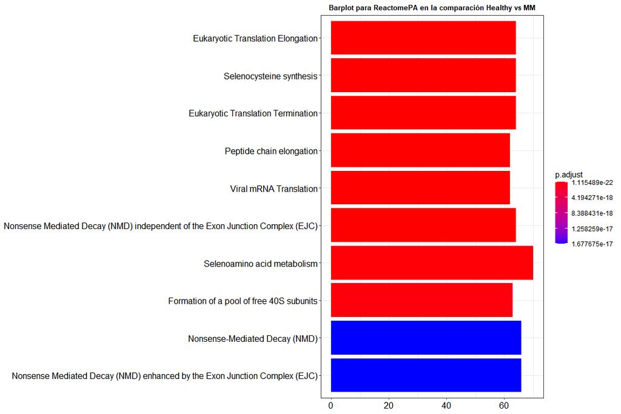

Figure 3.9: Barplot para los procesos biológicos enrriquecidos más significativamente en la comparación Healthy vs MM

```r
p <-  barplot(enrich.result, font.size = 12,showCategory = 10)

print(p + ggtitle("Barplot para ReactomePA en la comparación Healthy vs MM") + theme(plot.title = element_text(hjust = 0.5,size = 10, face = 'bold')))
```

```r
#Guardamos figura:
jpeg("Results/Figures/Enriched_Pathways_Log2FC_1_Padj0.05.jpeg", res = 200, width = 20, height = 16, units = 'in')
print(p + ggtitle("ReactomePA enriched biological processes \n Healthy vs MM") + theme(plot.title = element_text(hjust = 0.5,size = 30, face = 'bold')))
dev.off()
```

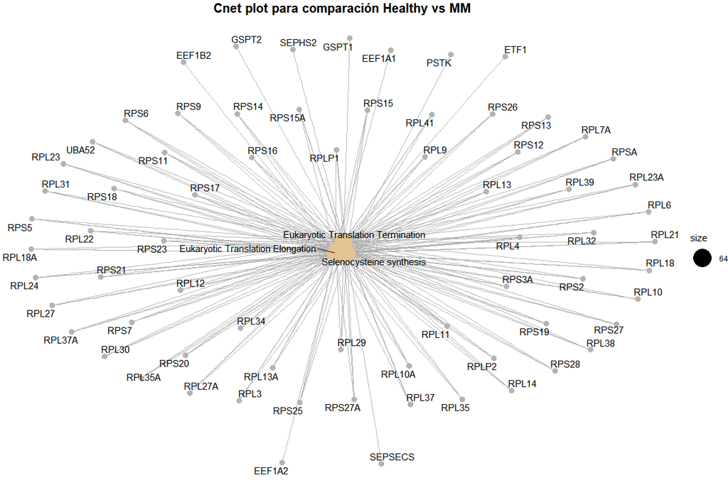

Figure 3.10: Gráfico de red con los procesos biológicos significativamente afectados en la comparación Healthy vs MM

```r
p <- cnetplot(enrich.result, showCategory = 3, vertex.label.cex = 3)

p <- print(p + ggtitle('Cnet plot para comparación Healthy vs MM') + theme(plot.title = element_text(hjust = 0.5,vjust = 2,face = 'bold',size = 15)))
```

```r
#Guardamos figura:
jpeg(file="Results/Figures/Cnet_plot_Healthy_MM.jpeg", res = 200, width = 20, height = 16, units = 'in')
p
dev.off()
```

# References

1. Alameda D, Goicoechea I, Vicari M, Arriazu E, Nevone A, Rodrı́guez S, et al. Tumor cells in light-chain amyloidosis and myeloma show different transcriptional rewiring of normal plasma cell development. Blood. 2021. doi:10.1182/blood.2020009754.

2. Anders S, Huber W. Differential expression analysis for sequence count data. Genome Biology. 2010;11. doi:10.1186/gb-2010-11-10-r106.

3. Love MI, Huber W, Anders S. Moderated estimation of fold change and dispersion for RNA-seq data with DESeq2. Genome Biology. 2014;15. doi:10.1186/s13059-014-0550-8.

4. McDermaid A, Monier B, Zhao J, Liu B, Ma Q. Interpretation of differential gene expression results of RNA-seq data: Review and integration. Briefings in Bioinformatics. 2018;20:2044–54. doi:10.1093/bib/bby067.

5. Zhu A, Ibrahim JG, Love MI. Heavy-tailed prior distributions for sequence count data: Removing the noise and preserving large differences. Bioinformatics. 2018;35:2084–92. doi:10.1093/bioinformatics/bty895.